# Statistik och dataanalys I

F7: Enkel linjär regression

Valentin Zulj

## Vad har vi gjort hittills?

- Förra gången pratade vi om linjära samband och **korrelationkoefficienten**
- Vi tittade bl.a. på sambandet mellan vikt och bränsleförbrukning för bilar, och sa att det verkade vara relativt linjärt

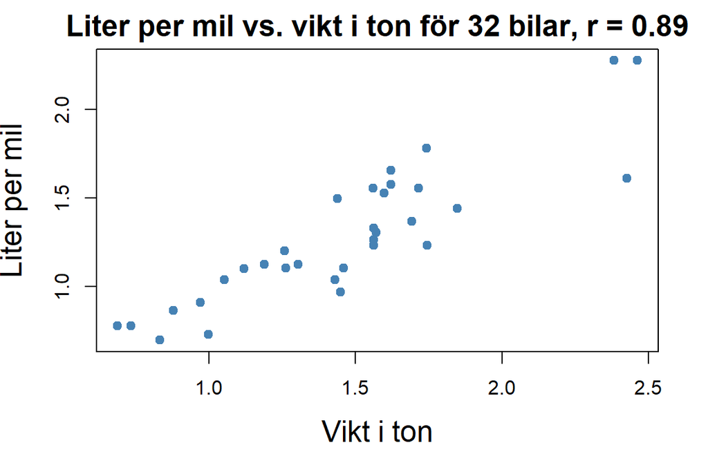

## Vad vi ska göra nu?

- Korrelationskoefficienten mäter styrkan på det linjära sambandet, men ger oss inte mycket mer information än så
- Antag att vi är intresserade av bränsleförbrukningen hos en bil som *inte finns med i vårt dataset*, men som vi vet väger *väger 2 ton*
- Även om korrelationen pekar på att vikt och förbrukting är linjärt relaterade, säger den inget om hur vi kan använda vikt för att förutspå förbrukning
- För att göra denna typ av **prediktion** kan använda **linjär regression**, som är vårt huvudfokus idag

# Enkel linjär regression

## Uppskatta värdet av y när du känner till värdet av x

- För att passa in i mönstret i vårt spridningsdiagram borde en bil som väger 2 ton förbruka ungefär 1.5–2 ton
- En sådan “gissning” kan i vissa fall vara tillräcklig, men hur gör vi om vi vill sätta **en** siffra på vår uppskattning av bensinförbrukningen?

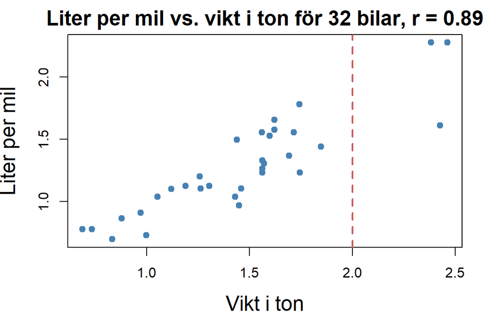

## Uppskatta värdet av y när du känner till värdet av x

- En metod för att uppskatta bensinförbrukningen när vi känner till vikten på en bil kan vara att dra en linje rakt genom svärmen av punkter
- Vi ser att vår linje är ungefär vid 1.7 på y-axeln när värdet på x-axeln är 2
- **Slutsats:** Vi uppskattar att en bil som väger 2 ton drar 1.7 liter per mil

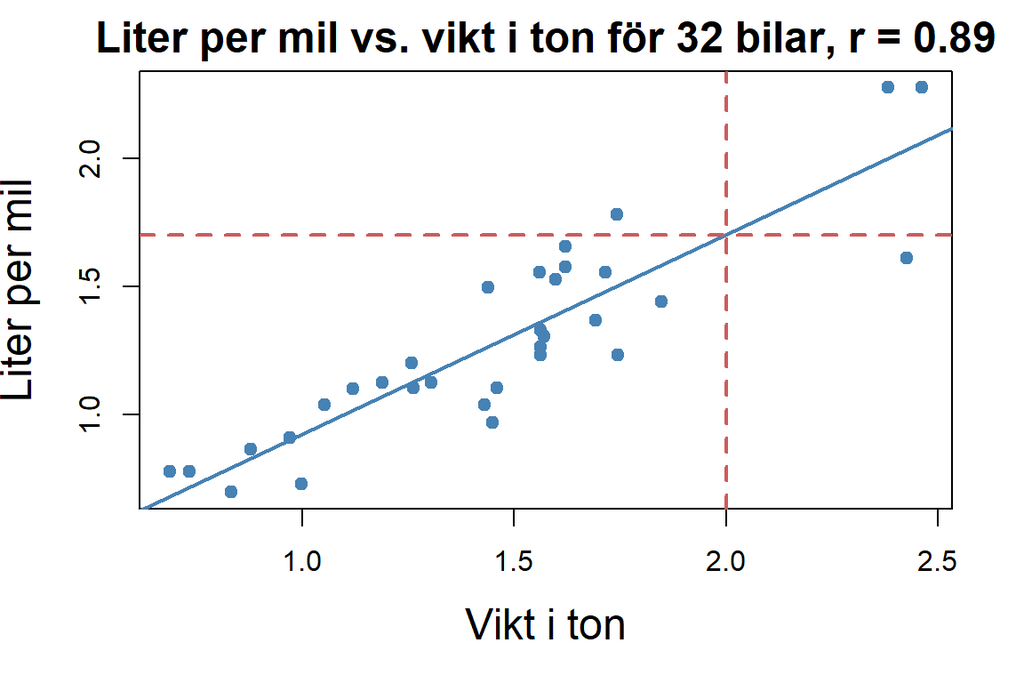

## Enkel linjär regression

- Analysen vi landade i på förra bilden kallas **enkel linjär regression**.
- Syftet med enkel linjär regression är vanligtvis att
  - Undersöka hur sambandet mellan $x$ och $y$ ser ut
  - **Prediktera** värdet på $y$ när vi känner till $x$

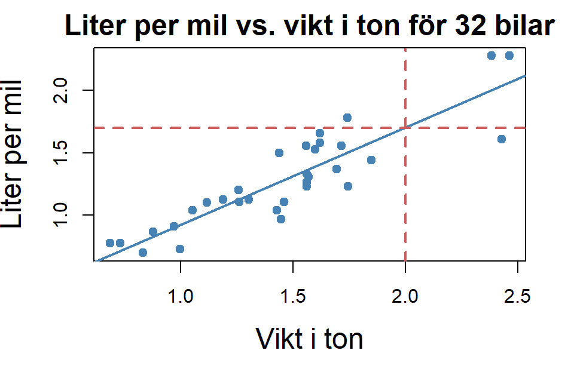

## Liten ordlista för enkel linjär regression (del 1)

- Att **prediktera** (*predict*) är att göra en uppskattning av ett värde när vi inte kan göra en direkt observation (dvs när vi inte kan göra en mätning)
- Substantivformen av ordet är **prediktion**
  - “Syftet med vår modell är att göra en prediktion av bensinförbrukningen”
- Vi kan säga **estimera** eller **skatta** på ungefär samma sätt som prediktera
  - “Vi estimerar/skattar bensinförbrukningen till 1.7 liter per mil”
- Substantivformerna är **estimat** och **skattning**
  - “Vårt estimat/Vår skattning är att bilen förbrukar 1.7 liter per mil”

## Liten ordlista för enkel linjär regression (del 2)

- Vår $y$-variabel kan kallas **responsvariabel**, eller den **beroende variabeln**
- Vår $x$-variabel kan kallas **förklaringsvariabel**, eller den **oberoende variabeln**
- Vi kallar det **enkel linjär regression** (*simple linear regression*) då modellen för $y$ bara bygger på **en enda** (en enkel) förklaringsvariabel
- I **multipel linjär regression** (*multiple linear regression*) använder vi **flera** förklaringsvariabler – men mer om detta någon annan gång

## Enkel linjär regression

- Rent intuitivt är linjär regression inte mer komplicerat än att dra en linje genom punktsvärmen, och läsa av vilket $y$-värde som passar ett givet $x$
- Men i praktiken krävs en del beräkningar för att bestämma exakt hur regressionslinjen bör dras för att ge en bra modell
- Vanligtvis vill vi också göra andra beräkningar som är kopplade till regressionsmodellen, t.ex. för att utvärdera hur bra modellen är
- Vi kommer titta närmare på dessa typer av beräkningar nu

## Regressionslinjen

- En regressionslinje kan definieras med två **regressionskoefficienter**:
  - **Intercept**: regressionslinjens $y$-värdet när $x=0$
  - **Lutning** (*slope*): anger hur många enheter $y$ ökar/minskar när $x$ ökar med en enhet
- Regressionslinjen på bilden har en lutning som är ungefär 0.8 och ett intercept strax över 0

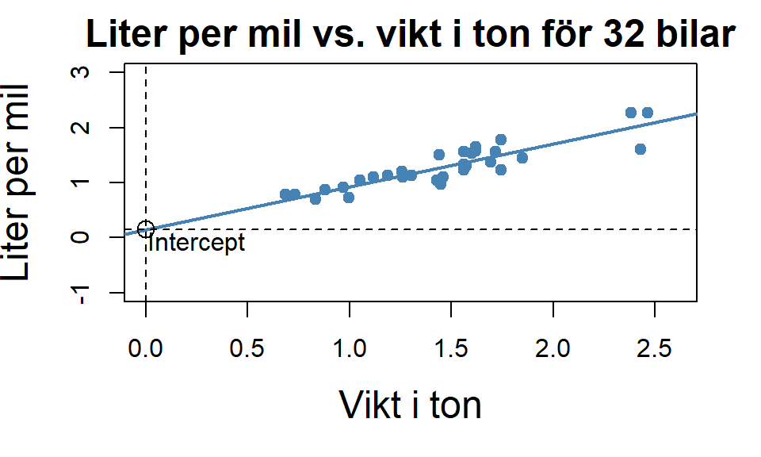

## Regressionslinjen

- Ren matematiskt skriver vi regressionslinjen som
  $$\hat{y} = b_0 + b_1 x$$
- Här betecknar $b_0$ är interceptet och $b_1$ är lutningen
- Jämför med vad ni vet om den räta linjens ekvation!
- Om vi har värden för $b_0$, $b_1$ och $x$ kan vi *skatta* $y$ – hatten över $y$ säger att $\hat y$ är en skattning av $y$
- Vid behov kan vi använda beskrivande variabelnamn istället för $x$ och $y$, t.ex.

$$\widehat{\text{litermil}} = b_0 + b_1 \text{vikt}$$

## Skillnaden mellan $y$ och $\hat y$

- Vi har redan nämnt “hatten” ovanför $y$ i formeln
  $$\hat{y} = b_0 + b_1 x$$
- Vi skriver som sagt $\hat{y}$ istället för $y$ då $\hat y$ är en **skattning** av $y$, och inte det verkliga värdet på $y$
- I vårt första exempel estimerade vi att bränsleförbrukningen är 1.7 liter/mil för en bil som väger 2 ton – i det fallet kunde vi skriva $\hat{y}=1.7$
- Om vi hade skrivit $y = 1.7$ hade vi hävdat att bilens **verkliga** förbrukning är 1.7 liter/mil – detta hade varit olämpligt, då estimat inte är perfekta

## Tolkning av enkel linjär regressionsmodell

- Ett vanligt syfte med en regressionsmodell är att skatta värdet på responsvariabeln m.h.a den förklarande variabeln, som vi precis har gjort
- Ett annat syfte kan vara att ge mer konkreta utsagor om sambandet
- Vår modell skattar bensinförbrukning hos en bil, med hjälp av dess vikt
- Vi kan skriva ut modellen som $\widehat{\text{litermil}} = b_0 + b_1 \cdot \text{vikt}$
- Anta att $b_0=0.146$ och $b_1=0.78$, då har vi

$$\widehat{\text{litermil}} = 0.146 + 0.78 \cdot \text{vikt}$$

## Tolkning av enkel linjär regressionsmodell

- Vi har alltså
  $$\widehat{\text{litermil}} = 0.146 + 0.78 \cdot \text{vikt}$$
- $b_1=0.78$ betyder att en bil, **enligt modellen**, förbrukar ytterligare 0.78 liter/mil bensin för varje extra ton som bilen väger
- $b_0=0.146$ betyder att en bil som väger 0 ton, **enligt modellen**, förbrukar 0.146 liter per mil
- I vårt fall är denna information inte meningsfull (varför?), så vi är försiktiga med att tolka interceptet bokstavligt

## Extrapolering

- Modellen blir mer osäker ju längre bort från punktsvärmen vi kommer
- Vi bör därför vara försiktiga med att använda modellen för att prediktera värden **utanför** det intervall av $x$ där våra datapunkter ligger
- I vårt exempel är det risky business att använda modellen för bilar som väger mindre än 0.5 ton eller mer är 2.5 ton

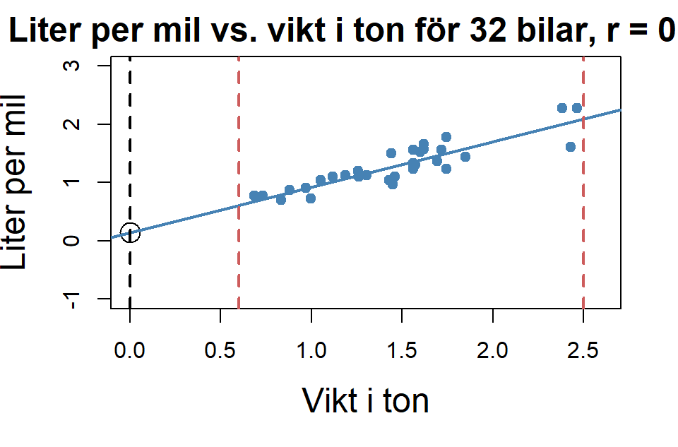

## Viktiga observationer om linjär regression

**OBS!**

- När vi tittade på korrelation betonade vi att korrelation inte är kausalitet
- Att $x$ har en stark korrelation till $y$ behöver inte betyda att $x$ orsakar $y$
- Samma sak gäller när vi tolkar lutningsparametern $b_1$ i en regressionsmodell
- Bara för att $b_1=0.78$ kan vi inte utan vidare säga att en viktökning med ett ton *medför* att bränsleförbrukningen ökar med 0.78 liter/mil
- Förändringen i bränsleförbrukning kan också påverkas av hur vikten fördelas, hur ansträngd bilens motor redan är, etc
- **Regressionsmodeller visar samband, inte kausalitet!**
- För att kunna hävda att ett ton i ökad vikt orsakar en viss ökning av bränsleförbrukningen måste andra vetenskapliga metoder användas

## Övning i regressionsanalys

- Bilden visar en linjär regressionsmodell, där varje observation är en student
- $x$-axeln visar antalet avslutade terminer och $y$-axeln antalet tagna poäng
- Fundera lite snabbt på frågorna
  1. Vilka värden har parametrarna $b_0$ och $b_1$?
  2. Hur ska parametrarna tolkas?
  3. Hur många poäng skattar modellen att en student har efter 2 terminer?

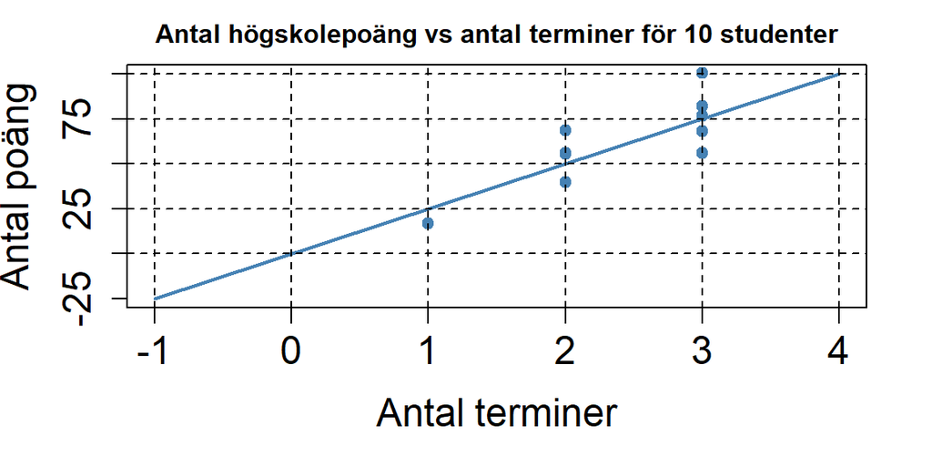

## Övning i regressionsanalys

**Frågor**

1. Vilka värden har parametrarna $b_0$ och $b_1$?
2. Hur ska parametrarna tolkas?
3. Hur många poäng skattar modellen att en student har efter 2 terminer?

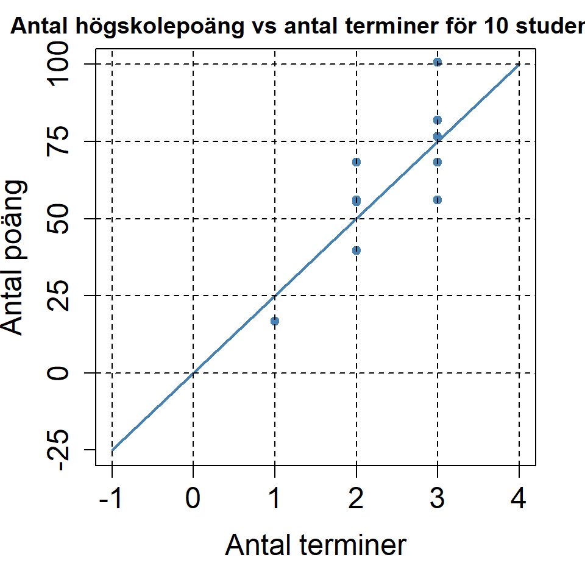

## Övning i regressionsanalys

1. Vilka värden har parametrarna $b_0$ och $b_1$?
   - Interceptet är värdet på $\hat y$ då $x = 0$, alltså har vi $b_0=0$
   - $\hat{y}$ ökar med 25 poäng för varje termin som $x$ ökar, alltså har vi $b_1=25$
2. Hur ska parametrarna tolkas?
   - $b_1$ kan tolkas som att antalet poäng ökar med 25 poäng per termin
   - $b_0$ kan tolkas som att en student som pluggat i 0 terminer har tagit 0 poäng
3. Hur många poäng skattar modellen att en student har efter 2 terminer?
   - Vår modell är $\widehat{\text{poäng}} = 0 + 25 \cdot \text{terminer}$, och efter 2 terminer är uppskatningen att en student har $0 + 25 \cdot 2=50$ poäng

## Regression mot medelvärdet

- **Regression mot medelvärdet:** (*regression to the mean*): En observation med ett avvikande $x$-värde resulterar i en prediktion $\hat{y}$ som är mindre avvikande
- **Exempel:** Anta att $x$ befinner sig 2 standardavvikelser från $\bar{x}$, då avviker $\hat{y}$ i regel med mindre än 2 standardavvikelser
- Avståndet mellan $\hat{y}$ och $\bar{y}$ är alltså mindre än avståndet mellan $x$ och $\bar{x}$, mätt i antalet standardavvikelser
- Vi kommer inte att fördjupa oss här, men “regression to the mean” är ett begrepp som är bra att känna till betydelsen av

## Residualer

- För varje observation kan vi räkna ut ett prediktion $\hat{y}= b_0 + b_1 x$
- För varje observerat $x$ har vi så både en prediktion från regressionslinjen ($\hat y$), och det *sanna* värdet $y$
- Skillnaden $e = y - \hat{y}$ kallas **residualen**(*the residual*), och vi har en residual för varje observation i datameterialet (se bild nedan)
- Residualerna kan vara positiva eller negativa – vad betyder det?

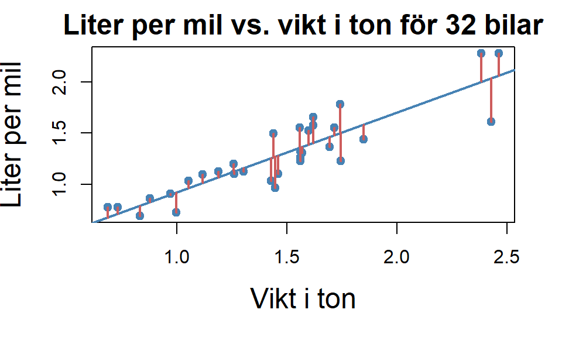

## Residualer

- Ju mindre residualerna är desto, bättre passar modellen ihop med observationerna

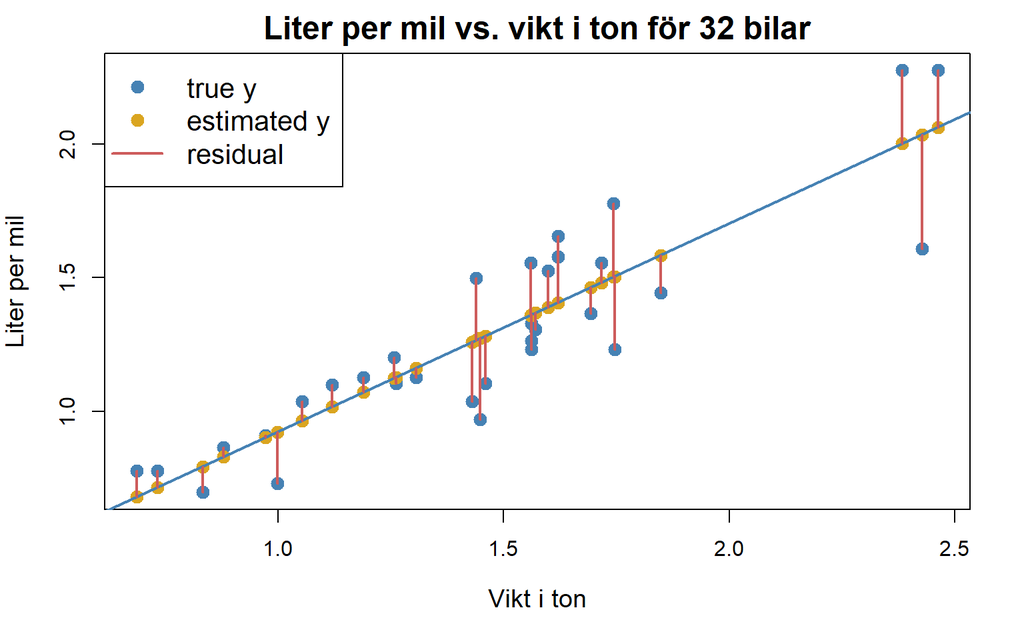

## Residualer och prediktionsfel

- I formeln $e = y - \hat{y}$ står $e$ alltså för residualen – $e$ som i *error*
- Residualen för en observation är ett mått på hur stort fel modellen gör när den skattar just den observationen
- Ju mindre residualerna är desto bättre fångar modellen observationerna i vårt datamaterial
- Vårt mål är att hitta en regressionslinje med så små residualer som möjligt
- Vi kan mäta den sammanlagda storleken på prediktionsfelen med summan
  $$\sum_{i = 1}^n{e_i^2} = e_1^2 + e_2^2 + e_3^2 + \ldots + e_n^2$$

## Minsta kvadratmetoden

- Vi betraktar den räta linje som minimerar $\sum_i e_i^2$ som den **bästa** regressionslinjen
- Eftersom vi minimerar de **kvadrerade** prediktionsfelen, kallas denna skattningsmetod för **minsta kvadratmetoden** (*method of least squares*)
- Linjen som minimerar $\sum_i e_i^2$ skrivs (enligt tidigare) som
  $$\hat{y} = b_0 + b_1 x$$
- Nu kan vi dock lägga till att värdena som minimerar kvadratsumman är
  $$b_1 = r_{x,y} \cdot \cfrac{s_y}{s_x},
  \; \text{ och } \;
  b_0 = \bar{y} - b_1 \bar{x}$$

## Minsta kvadratmetoden

- Minsta kvadratmetoden ger som sagt
  $$b_1 = r_{x,y} \cdot \cfrac{s_y}{s_x},
  \; \text{ och } \;
  b_0 = \bar{y} - b_1 \bar{x}$$
- Vi ser så att vi kan beräkna $b_0$ och $b_1$ med hjälp av
  - Korrelationskoefficienten $r$
  - Standardavvikelserna $s_x$ och $s_y$
  - Medelvärdena $\bar x$ och $\bar y$
- Alla dessa känner vi igen sedan tidigare

## Minsta kvadratmetoden i R

- Som exempel använder vi datamaterialet med bränsleförbrukning och vikt
- Vi kallar förbrukning för `litermil` och vikt för `viktton`
- Vi gör det på två sätt, först med formlerna och sedan med funktionen `lm()`

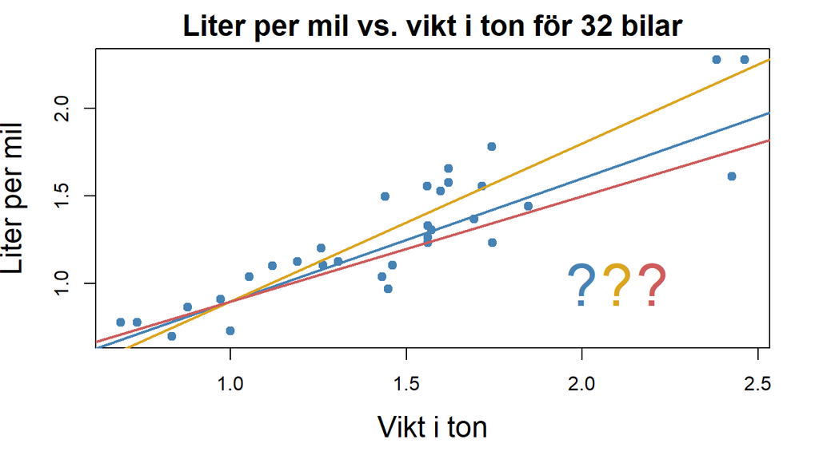

## Minsta kvadratmetoden i R – beräkning med formler

- Vi kommer ihåg att vi kan beräkna $b_0$ och $b_1$ med hjälp av
  - korrelationscoefficienten $r$
  - standardavvikelserna $s_x$ och $s_y$
  - våra medelvärden $\bar{x}$ och $\bar{y}$
- I R kör vi

```r
r <- cor(mtcars$litermil, mtcars$viktton) # Korrelation
sx <- sd(mtcars$viktton)  # Standardavvikelse x
sy <- sd(mtcars$litermil) # Standardavvikelse y
xbar <- mean(mtcars$viktton)  # Medelvärde x
ybar <- mean(mtcars$litermil) # Medelvärde y
sprintf("r=%.2f, sx=%.2f, sy=%.2f, xbar=%.2f, ybar=%.2f",
        r, sx, sy, xbar, ybar)
```

```
[1] "r=0.89, sx=0.44, sy=0.39, xbar=1.46, ybar=1.28"
```

## Minsta kvadratmetoden i R – beräkning med formler

- Med hjälp av dessa siffror kan vi beräkna
  $$b_1 = r_{x,y} \cfrac{s_y}{s_x}, \; \text{och} \; b_0 = \bar{y} - b_1 \bar{x}$$

```r
b1 <- r * sy / sx
b0 <- ybar - b1 * xbar
sprintf("b0=%f, b1=%f", b0, b1)
```

```
[1] "b0=0.145934, b1=0.778348"
```

- Vår modell är alltså
  $$\widehat{\text{litermil}} = 0.145934 + 0.778348 \cdot \text{vikt}$$
- Notera att vi även kan beräkna $r$, $s_x$ och $s_y$ med egna formler istället för `cor()` och `sd()`

## Enkel linjär regression - beräkning med lm()

- Nu gör vi samma beräkning med funktionen `lm()`

```r
my_regressionmodel <- lm(litermil ~ viktton, data=mtcars)
summary_model <- summary(my_regressionmodel)
summary_model$coefficients
```

```
             Estimate Std. Error   t value     Pr(>|t|)
(Intercept) 0.1459341 0.11106493  1.313953 1.988214e-01
viktton     0.7783476 0.07284538 10.684928 9.565824e-12
```

- Modellparametrarna återges i kolumnen `"Estimate"`, och vi har att
  - *(Intercept)* är vårt $b_0$,
  - *viktton* är vårt $b_1$ ($b_1$ hör till den variabeln `viktton`)

# Slump och signifikans

## P-värde i regressionsoutput

```
             Estimate Std. Error   t value     Pr(>|t|)
(Intercept) 0.1459341 0.11106493  1.313953 1.988214e-01
viktton     0.7783476 0.07284538 10.684928 9.565824e-12
```

- Kolumnen längst till höger kallas `Pr(>|t|)`, och innehåller **p-värden**, som har med **statistiskt signifikans** att göra
- Det är vanligt att betrakta en koefficientskattning statistiskt signifikant om p-värdet är lägre än 0.05, men det är upp till bedömaren var gränsen ska går
- Det är viktigt att komma ihåg att statistisk signifikans inte medför praktisk signifikans – det är kontexten som sätter värde på statistisk signifikans
- Inom medicin brukar man t.ex. skilja statistisk signifikans från klinisk signifikans

## Slump och signifikans

- Vi kommer inte beräkna signifikans för hand i den här delkursen (det kommer på Jonas del), men vi ska gå igenom konceptet
- Mer specifikt är vi intresserade av signifikansen i lutningskoefficenten $b_1$ (vi struntar vanligtvis i $b_0$)
- Notera först att vårt dataset `mtcars` bara innehåller data om 32 bilmodeller
- Om vi hade haft 32 andra bilmodeller i vår data hade regressionslinjen sett annorlunda ut
- Mattias Villini har tagit fram en widget som låter er titta mer på detta https://statisticssu.github.io/SDA1/observable/linreg_simple.html

## Slump och signifikans

- Vi säger att parametern $b_1$ är **signifikant** om vi drar slutsatsen att sambandet vi har hittat i våra data gäller generellt för **alla** bilmodeller
- Med andra ord drar vi slutsatsen att sambandet inte beror på **slumpen**, ungefär som vi har diskuterat tidigare
- När vi säger att ett samband **inte** är signifikant menar vi att sambandet i vår data mycket väl kan vara orsakat av slumpen
- När vi säger att ett samband **är** signifikant menar vi att sambandet i vår data med största sannolikhet *inte* är ett resultat av slumpen
- **Kom ihåg:** Att ett samband är signifikant i statistisk mening behöver inte betyda att sambandet är *betydelsefullt* i mer allmän bemärkelse!

## Slump och signifikans

- Vi har redan sett att p-värdet för $b_1$ är väldigt lågt i vårt exempel med bilars vikt och bensinförbrukning, vilket visar statistisk signifikans.
- Nu ska vi visa på ett annat sätt att $b_1$ är signifikant
- Om det inte fanns ett samband mellan bensinförbrukning och vikt, då kunde vilken bensinförbrukning som helst ha varit kopplad till vilken vikt som helst
- Vi ska visa några grafer för hur det slumpvisa utfallet kan bli om det saknas samband mellan vikt och bensinförbrukning (se nästa slide)

## Slump och signifikans

- Den första grafen är vår ursprungliga graf, de övriga graferna visar hur det slumpvisa utfallet kan bli om det saknas ett verkligt samband

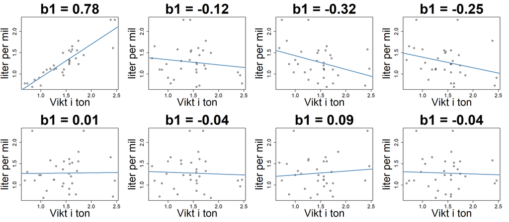

## Slump och signifikans

- Nu slumpar vi fram 1000 dataset utifrån hypotesen att det saknas koppling mellan vikt och bensinförbrukning
- För varje dataset räknar vi ut lutningskoefficienten $b_1$
- Histogrammet visar hur de 1000 lutningskoefficienterna $b_1$ fördelar sig

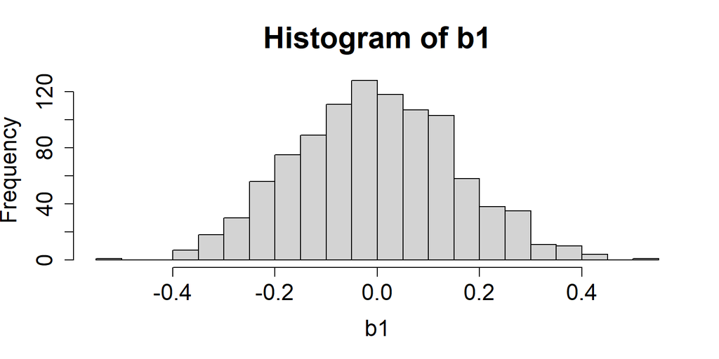

## Slump och signifikans

- Vi ser att **ingen** av de slumpvisa koefficienterna är så stor som 0.78
- Slutsatsen blir att slumpen troligtvis inte orsakade det samband som vi såg i vår data, och därför betraktar vi sambandet som signifikant

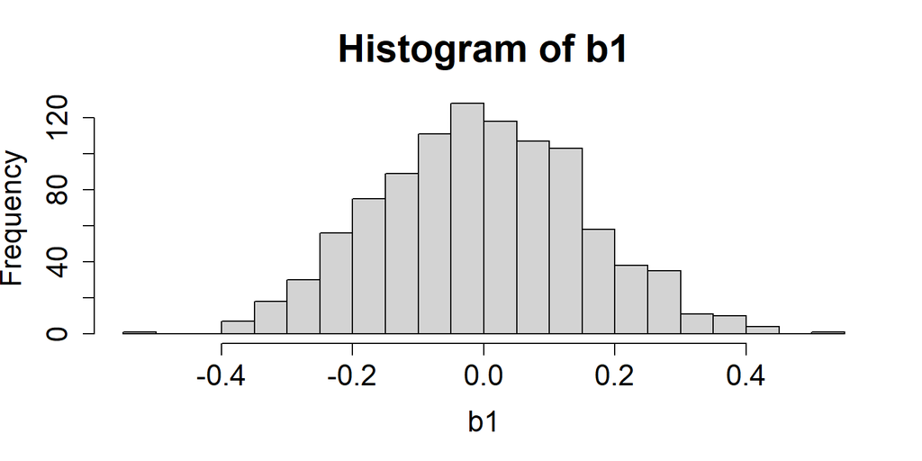

# Modellantaganden och residualanalys

## Residualanalys

- Vi har redan introducerat residualerna, och beskrivit hur de används för att hitta den bästa regressionslinjen (linjen som minimerar $\sum_i e_i^2$)
- Nu återvänder vi till residualerna, och går igenom hur de kan användas för att utvärdera våra **modellantaganden**
- Modellantaganden är antaganden som måste vara uppfyllda för att våra resultat ska vara tillförlitliga

## Residualanalys

- Statistiska modeller bygger ofta på antaganden, regressionsanalys likaså
- När vi använder regressionsanalys gör vi följande två antaganden:
  1. Residualerna är **normalfördelade**
  2. Residualernas **varians är konstant**
- Dessa antaganden är främst relevanta när vi vill räkna ut felmarginaler för våra skattade värden
- Vi ska inte göra sådana beräkningar här, men det är bra att redan nu skapa vanan att kontrollera residualernas mönster
- Vi använder framför allt två typer av grafer för residualanalysen
  - Residualgrafer (residual plots)
  - Normalfördelningsgrafer

## Residualgrafer

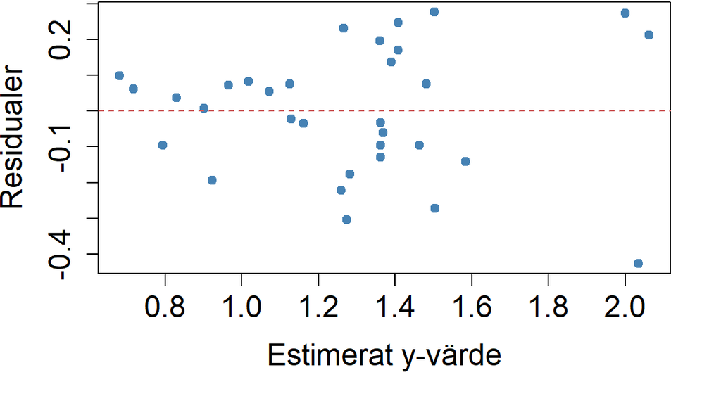

- Figuren visar en **residualgraf** för vår regressionsmodellmodell, där $x$-axeln visar varje skattning av $y$, och på $y$-axeln visar residualen $e$
- Om residualplotten inte visar något tydligt mönster utan ser slumpmässig ut så är det ett gott tecken

## Residualgrafer

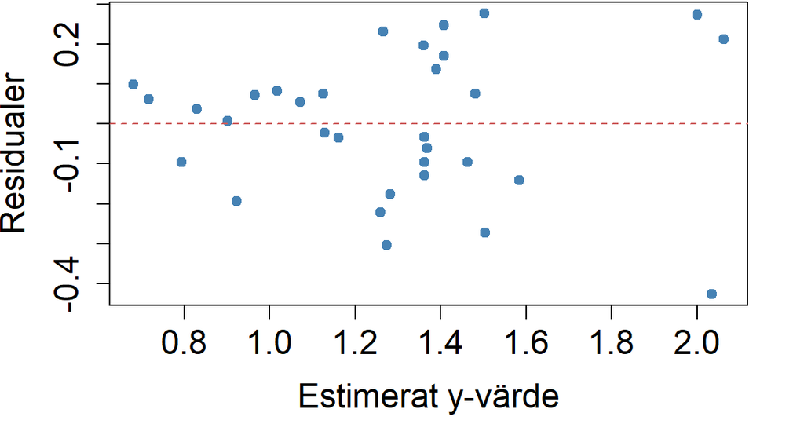

- Om vi ser tydliga **outliers** bland residualerna så representerar de observationer som inte passar väl in i modellen
- Det kan finnas anledning att studera dessa observationer för att förstår varför de skiljer ut sig

## Residualgrafer

- **Sammanfattningsvis om residualgrafer**

> “A scatterplot of the residuals vs. the x-values should be the most boring scatterplot you’ve ever seen. It shouldn’t have any interesting fatures, like direction or shape.”

DeVeaux et al (2021), page 238

## Normalfördelningsgraf

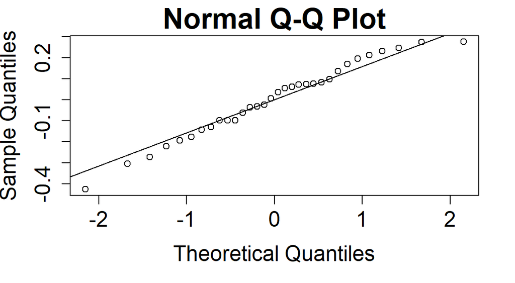

- På den här bilden ser vi en **normalfördelninggraf** för samma modell
- Om residualerna är normalfördelade ska punkterna följa linjen på ett ungefär, vilket de i det här fallet gör

## Antaganden uppfyllda

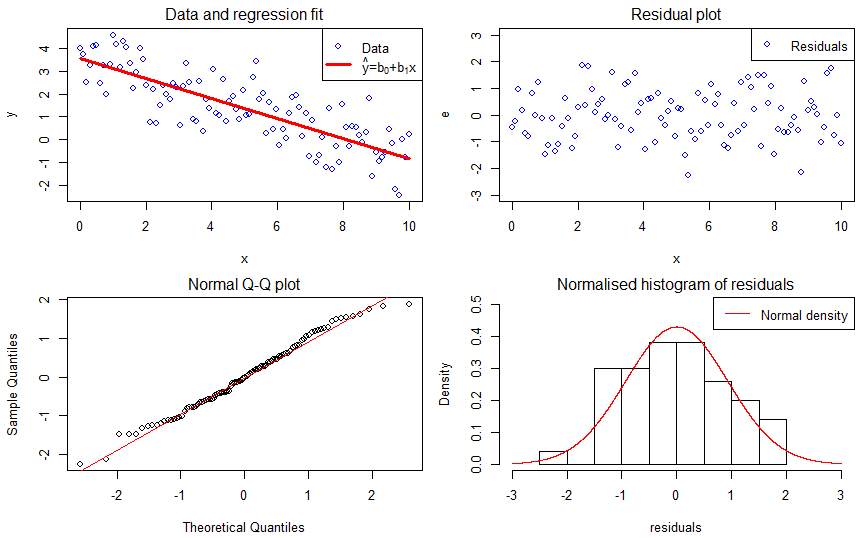

## Residualer som inte är normalfördelade

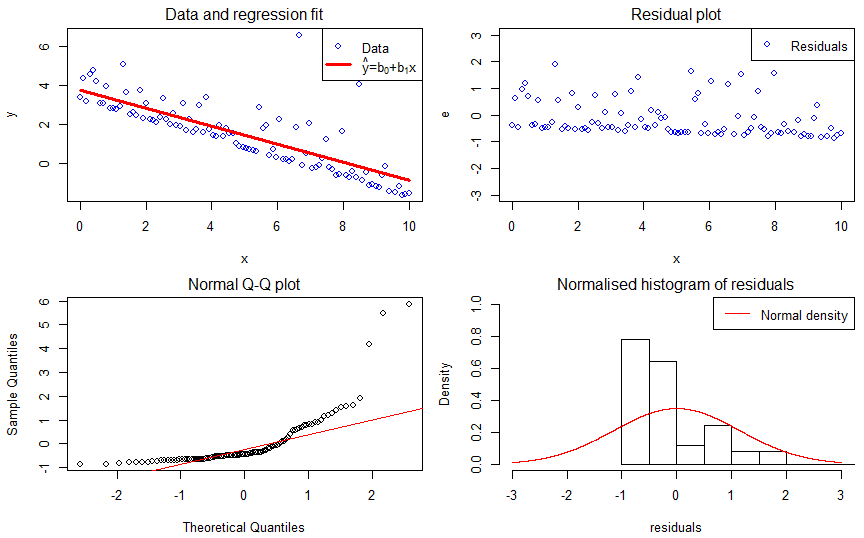

## Residualer som inte har konstant varians

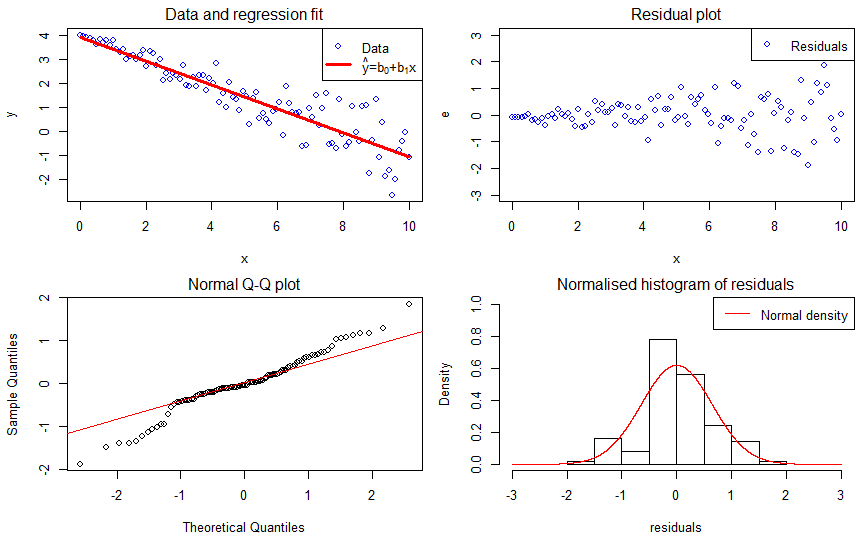

## Residualer som inte har slumpmässigt mönster

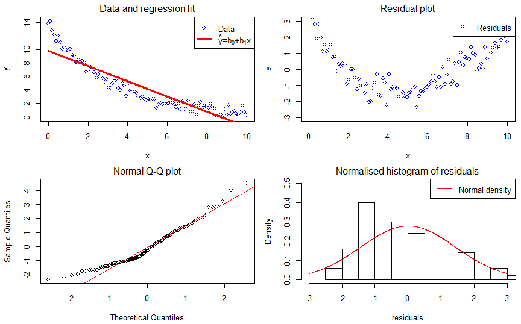

## Residualanalys i R

Så här kan vi skapa en residualgraf med R.

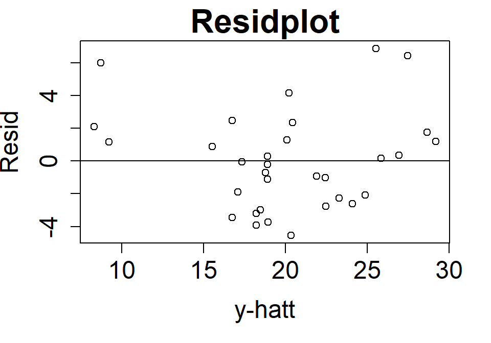

```r
lmod2 <- lm(mpg ~ wt, data=mtcars) #Skapa en modell
mtcars$res <- resid(lmod2) # Skapa en vektor med residualerna
mtcars$y_hatt <- fitted(lmod2) # Estimerade y-värden
plot(mtcars$res ~ mtcars$y_hatt, ylab="Resid", xlab="y-hatt",
     main="Residplot")
abline(h=0) #Dra en linje genom residualgrafen vid 0
```

## Residualanalys i R

Så här kan vi skapa en normalfördelningsgraf med R.

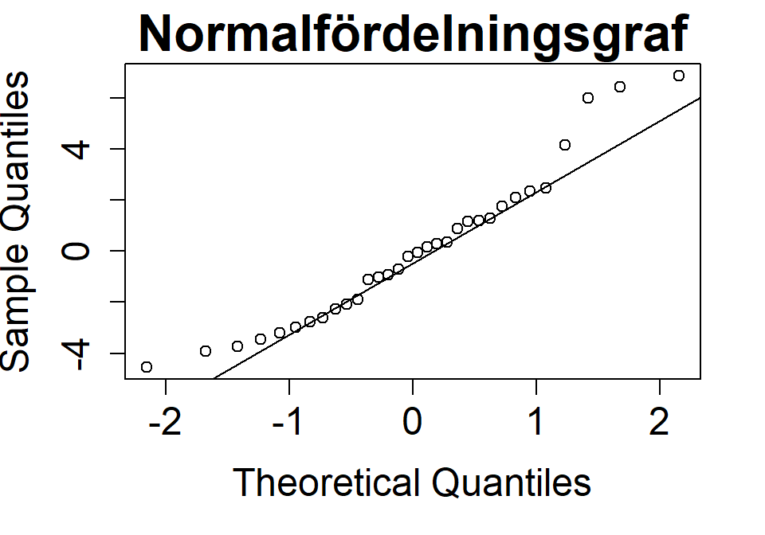

```r
qqnorm(resid(lmod2), main="Normalfördelningsgraf") #Rita graf
qqline(resid(lmod2)) #Lägg till en linje i grafen
```

# Förklaringsgraden $R^2$

## Förklaringsgrad

- $R^2$, som uttalas **R-kvadrat/R-två** (*en: R-squared*), kan användas som ett mått på hur bra en regressionsmodell är
- $R^2$ berättar hur väl modellen **förklarar variationen** i responsvariabeln
- För att förstå vad som menas med detta börjar vi medden **enklaste tänkbara modellen** som inte innehåller någon förklaringsvariabel
- Den enklaste sådana modellen innehåller bara interceptet, alltså $\hat{y} = b_0$
- I en regressionsmodell med bara interceptet blir $b_0=\bar{y}$, dvs skattningen blir alltid detsamma som variabelns medelvärde

## Enkel linjär regression - R-kvadrat

- Modellen $\hat{y} = b_0$ representeras av den gula linjen i bilden
- Modellen gör samma prediktion för alla bilar, och ger därmed **ingen** förklaring till varför förbrukningen varierar mellan modeller

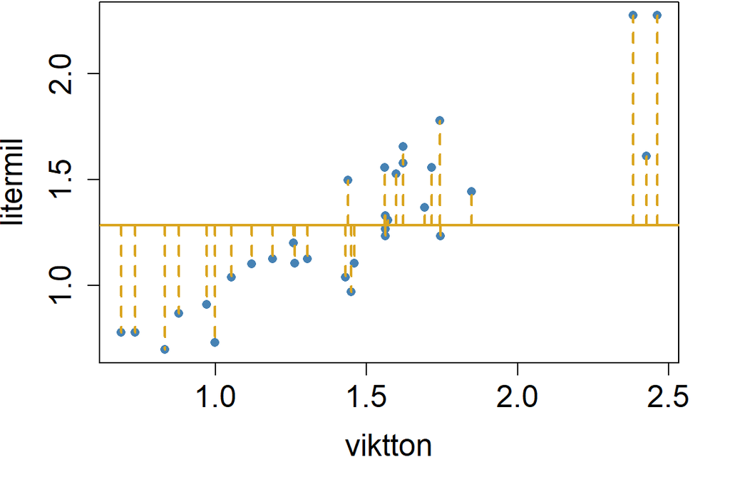

## Förklaringsgrad

- Vi lägger nu till *vikt* som förklarande variabel, och får modellen $\hat{y} = b_0+b_1x$ (bild till höger)
- Modellen till höger **förklarar en stor del av variationen** med att högre vikt är associerat med högre bensinförbrukning
- Den variation som fortfarande är oförklarad illustreras med streckade linjer

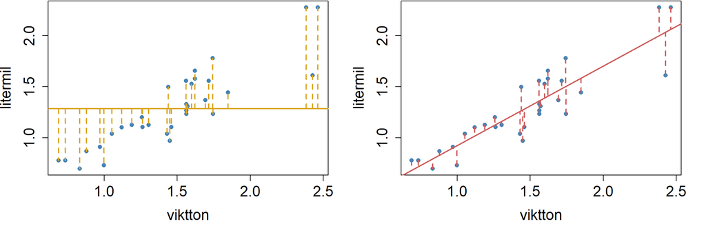

## Förklaringsgrad

- $R^2$ anger hur stor **andel** av variationen i $y$ som en modell förklarar
- Som exempel betyder alltså $R^2 = 0.6$ att modellen förklarar 60% av den totala variationen i $y$
- För att räkna ut $R^2$ för en modell behöver vi två nya begrepp
  - **SST (Sum of Squares Total):** Den totala variationen i responsvariabeln
  - **SSE (Sum of Squares Error):** Den variation som inte förklaras av modellen

## Förklaringsgrad

- Vi kan räkna ut SST och SSE med formlerna

$$\text{SST}=\sum_{i=1}^n (y_i - \bar{y})^2, \; \text{ och } \; \text{SSE} = \sum_{i=1}^n(y_i - \hat{y})^2$$

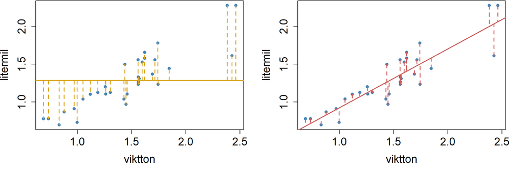

## Förklaringsgrad

När vi har räknat ut $\text{SST}$ och $\text{SSE}$ kan vi räkna ut $R^2$ som

$$R^2 = 1 - \cfrac{SSE}{SST}$$

- Uttrycket $SSE/SST$ är andelen av den totala variationen som modellen lämnar *oförklarad*
- $R^2 = 1 - SSE/SST$ är därför den andel som *är* förklarad
- $SSE \leq SST$, vilket innebär att $0 \leq R^2 \leq 1$
- Notera: i den enkla modellen är $\hat{y} = \bar{y}$, och $\text{SSE} = \text{SST}$, vilket ger $R^2=0$
- Om en modell har $R^2=1$ betyder det att alla ligger observationer exakt på regressionslinjen

## Förklaringsgrad

- I enkel linjär regression gäller att $R^2=r^2$, där $r$ är korrelationskoefficienten mellan $y$-variebeln och $x$-variabeln
- I multipel regression kan vi istället sätta $r$ till korrelationen mellan $y$ och $\hat{y}$
- Det går inte att säga generellt vad ett som är ett bra värde på $R^2$
- I vissa naturvetenskaper kan det förekomma att $R^2$ är nära 1
- I samhällsvetenskaper är det vanligt med modeller där $R^2$ är en bra bit under 0.5
- Det kan bero på att samhällsfenomen har många bidragande orsaker, vilket gör det svårt att mäta/inkludera mer än ett fåtal av dem i en modell

## Förklaringsgrad

- Nedan ser vi två figurer ur Walpole et al. (2016)
  - I figuren till vänster förklarar modellen nästan all variation
  - I figuren till höger förklara modellen nästan ingen del av variationen

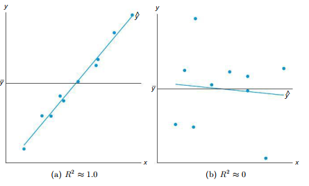

## Förklaringsgrad

- Vi ha talat om SST och SSE
- Ett tredje begrepp är **SSR (Sum of Squares Regression)**, som mäter variationen av $\hat{y}$ runt variabelns medelvärde $\bar{y}$

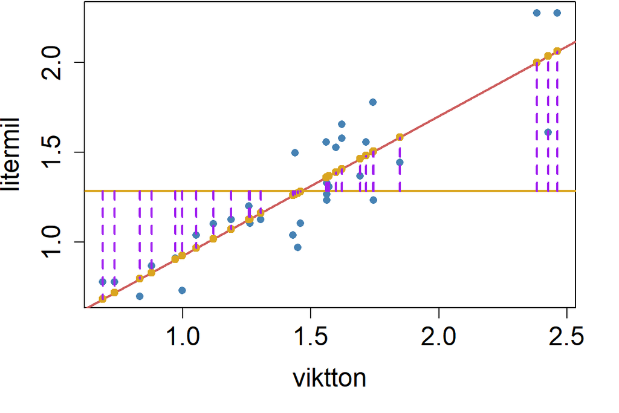

## Förklaringsgrad

- Vi räknar ut SSR med formeln

$$\text{SSR} = \sum_{i=1}^n (\hat{y} - \bar{y})^2$$

- SST, SSR och SSE förhåller sig till varandra på så sätt att
  $$SST = SSR + SSE$$
- Vi kan därför även beräkna $R^2$ som
  $$R^2 = \cfrac{SSR}{SST}$$
- Att dela upp variansen på det här sättet kallas **Analysis of variance (ANOVA)**

## Enkel linjär regression - R-kvadrat

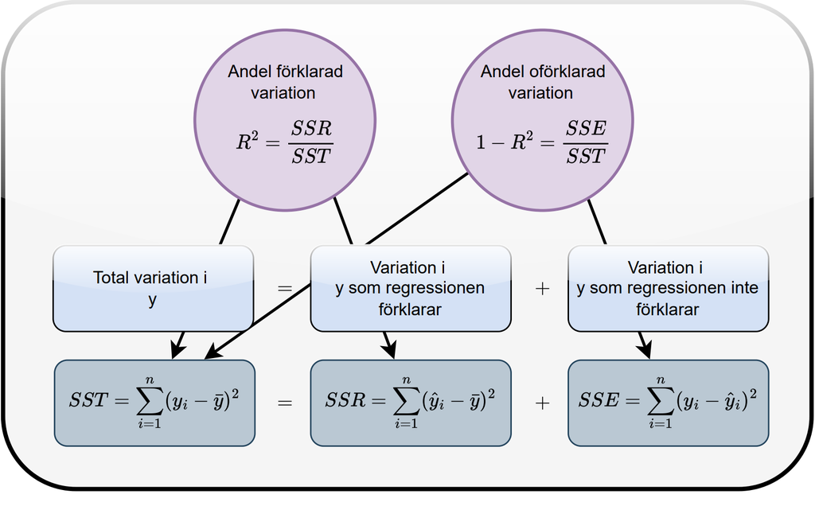

## Förklaringsgrad

- Nu ska vi räkna ut $R^2$ för vår modell som estimerar responsvariabeln bensinförbrukning med förklaringsavariabeln vikt
- Först räknar vi ut SST, SSR och SSE

```r
lmod <- lm(litermil~viktton, data=mtcars)
y <- mtcars$litermil
y_hatt <- fitted(lmod)

SST <- sum((y - mean(y))^2)
SSR <- sum((y_hatt - mean(y))^2)
SSE <- sum((y - y_hatt)^2)

sprintf("SST = %.3f, SSR = %.3f, SSE = %.3f", SST, SSR, SSE)
```

```
[1] "SST = 4.680, SSR = 3.706, SSE = 0.974"
```

## Enkel linjär regression - R-kvadrat i R

- Vi såg att SST = 4.680, och jämför med $SSR + SSE$ för att bekräfta $SSR+SSE=SST$

```r
sprintf("SSR + SSE = %.3f", SSR + SSE)
```

```
[1] "SSR + SSE = 4.680"
```

- Sedan räknar vi ut $R^2$ med formeln $R^2 = 1 - \cfrac{SSE}{SST}$

```r
R2 <- 1 - SSE/SST
sprintf("With the formula 1 - SSE/SST we get R2 = %.4f", R2)
```

```
[1] "With the formula 1 - SSE/SST we get R2 = 0.7919"
```

## Enkel linjär regression - R-kvadrat i R

Vi ser att *lm* räknar ut samma värde för R-squared.

```r
summary(lmod)
```

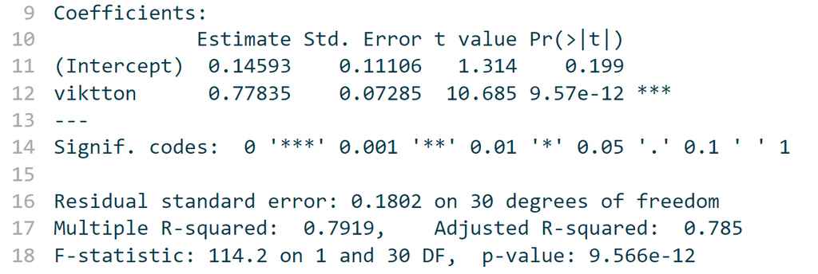

## Credits

Dessa slides skapades av Karl Sigfrid för kursen Statistik och Dataanalys I och har uppdaterats av Oskar Gustafsson och Valentin Zulj